# Exercise 05

`## [1] 2.087024`

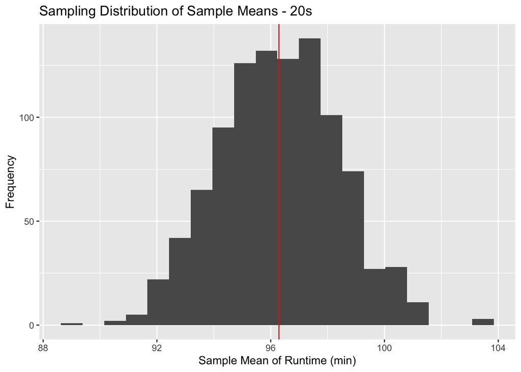

`## [1] 0.7543859`

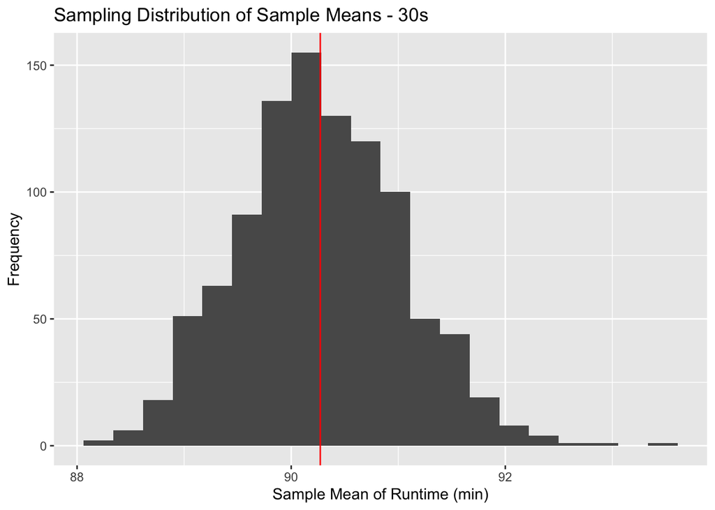

`## [1] 0.6765833`

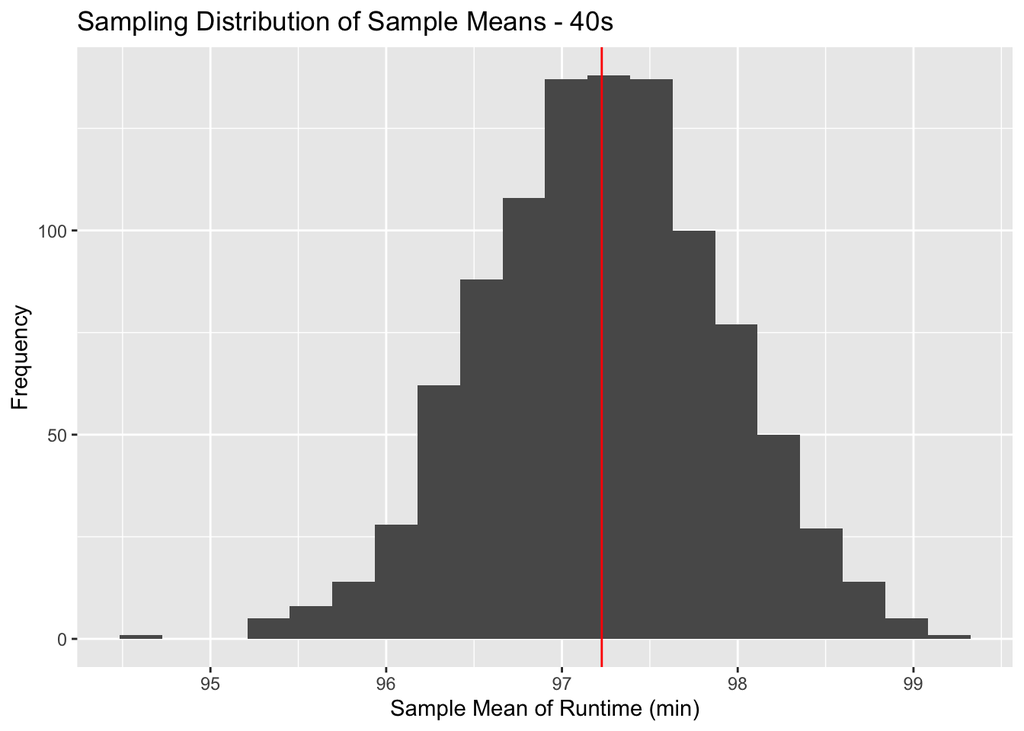

`## [1] 0.581883`

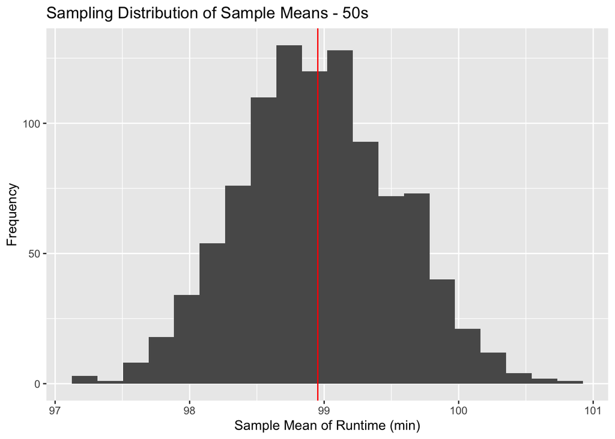

`## [1] 0.5545719`

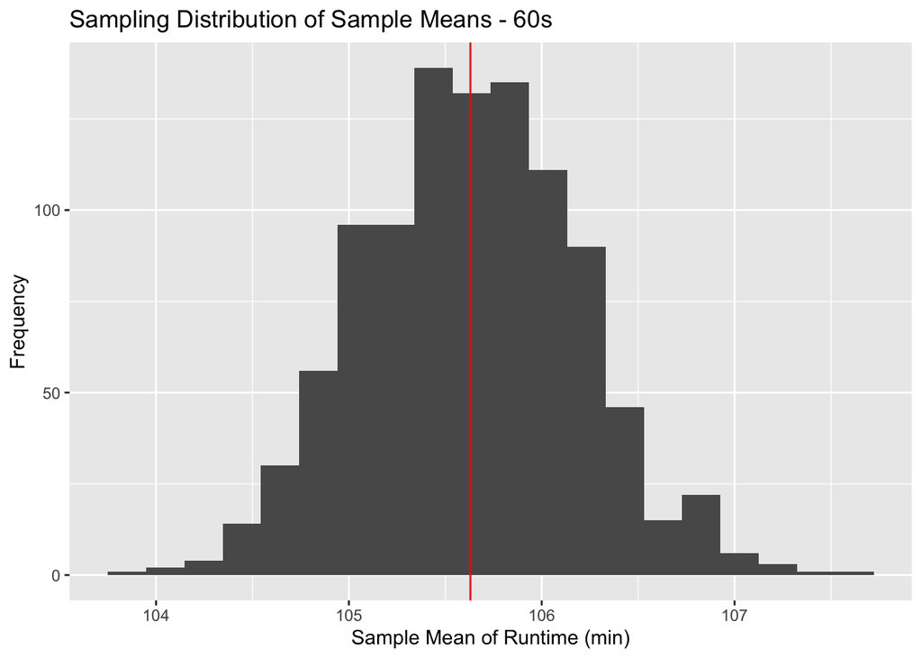

`## [1] 0.4431`

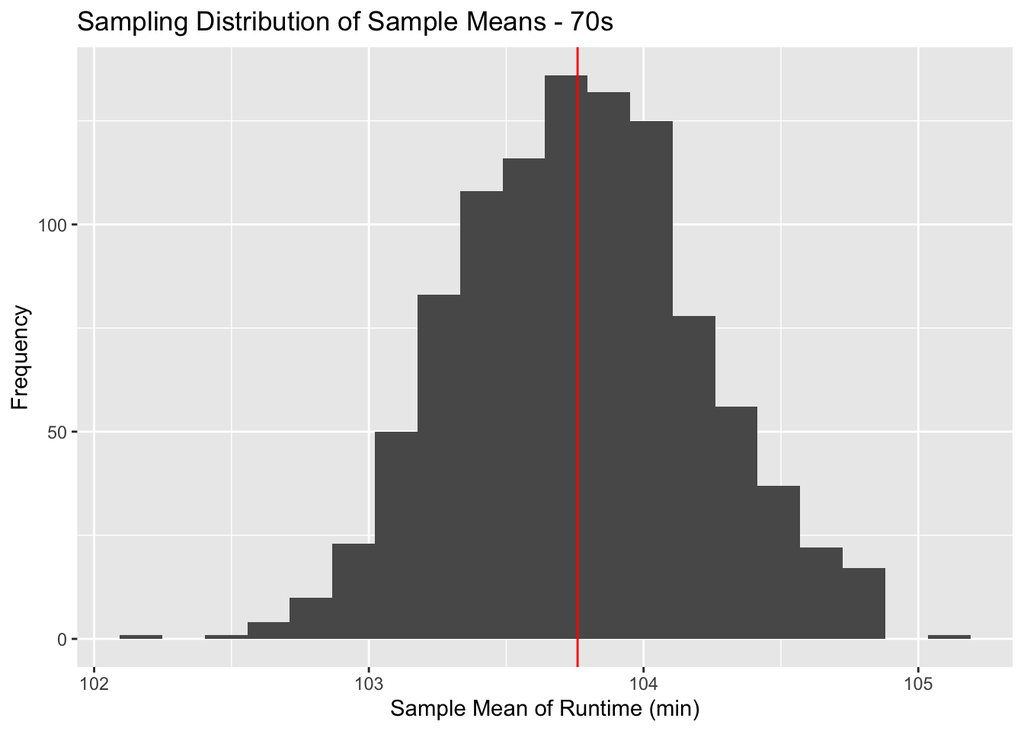

Step 10:

Compare the standard error in runtimeMinutes for samples of size 100 from each decade:

[1] as estimated from your first sample of 100 movies [2] as calculated from the known population standard deviations for each decade [3] as estimated from the sampling distribution of sample means for each decade.